# Exploring Palmer Penguins

Sofia Rodriguez

# Introduction

This report explores the Palmer Penguins dataset. I will examine differences among penguin species, sexes, and island locations using summary tables and graphs.

# Exploratory Analysis

```r
# Examine the beginning of the penguins dataframe.
head(penguins)
```

```
## # A tibble: 6 × 8
##   species island    bill_length_mm bill_depth_mm flipper_length_mm body_mass_g
##   <fct>   <fct>              <dbl>         <dbl>             <int>       <int>
## 1 Adelie  Torgersen           39.1          18.7               181        3750
## 2 Adelie  Torgersen           39.5          17.4               186        3800
## 3 Adelie  Torgersen           40.3          18                 195        3250
## 4 Adelie  Torgersen           NA            NA                  NA          NA
## 5 Adelie  Torgersen           36.7          19.3               193        3450
## 6 Adelie  Torgersen           39.3          20.6               190        3650
## # ℹ 2 more variables: sex <fct>, year <int>
```

## Dataset size

The following code checks how many columns and penguin observations are in the dataset.

```r
# Count the columns and rows in the penguins dataframe.
ncol(penguins)
```

```
## [1] 8
```

```r
nrow(penguins)
```

```
## [1] 344
```

## Representation by sex

The following code checks whether male and female penguins are represented equally in the dataset.

```r
# Count male, female, and missing sex values.
table(penguins$sex, useNA = "ifany")
```

```
##
## female   male   <NA>
##    165    168     11
```

```r
# Create dataframes containing only male or female penguins.
pmale <- penguins[
  !is.na(penguins$sex) & penguins$sex == "male",
]

pfemale <- penguins[
  !is.na(penguins$sex) & penguins$sex == "female",
]

# Confirm the number of rows in each dataframe.
nrow(pmale)
```

```
## [1] 168
```

```r
nrow(pfemale)
```

```
## [1] 165
```

## Representation by species

The following code checks whether each penguin species is represented equally in the dataset.

```r
# Count the penguins in each species.
table(penguins$species, useNA = "ifany")
```

```
##
##    Adelie Chinstrap    Gentoo
##       152        68       124
```

```r
# Create one dataframe for each species.
pAdel <- penguins[penguins$species == "Adelie", ]
pChin <- penguins[penguins$species == "Chinstrap", ]
pGen <- penguins[penguins$species == "Gentoo", ]

# Confirm the number of rows in each dataframe.
nrow(pAdel)
```

```
## [1] 152
```

```r
nrow(pChin)
```

```
## [1] 68
```

```r
nrow(pGen)
```

```
## [1] 124
```

## Representation by island

The following code checks whether each island is represented equally in the dataset.

```r
# Count the penguins observed on each island.
table(penguins$island, useNA = "ifany")
```

```
##
##    Biscoe     Dream Torgersen
##       168       124        52
```

```r
# Create one dataframe for each island.
iBis <- penguins[penguins$island == "Biscoe", ]
iDream <- penguins[penguins$island == "Dream", ]
iTorg <- penguins[penguins$island == "Torgersen", ]

# Confirm the number of rows in each dataframe.
nrow(iBis)
```

```
## [1] 168
```

```r
nrow(iDream)
```

```
## [1] 124
```

```r
nrow(iTorg)
```

```
## [1] 52
```

# Data Visualization

## Measurements that distinguish male and female penguins

Body mass may help distinguish male and female penguins. The plot below compares body mass by sex while separating the three species.

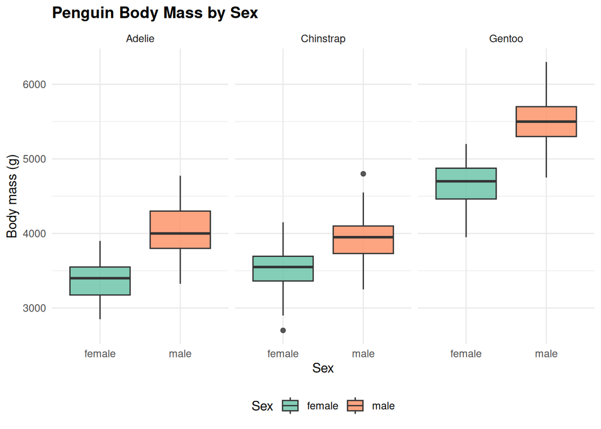

```r
# Remove rows with missing sex or body-mass values before plotting.
penguins_sex <- penguins[
  !is.na(penguins$sex) & !is.na(penguins$body_mass_g),
]

ggplot(
  data = penguins_sex,
  aes(x = sex, y = body_mass_g, fill = sex)
) +
  geom_boxplot(alpha = 0.8) +
  facet_wrap(~ species) +
  labs(
    title = "Penguin Body Mass by Sex",
    x = "Sex",
    y = "Body mass (g)",
    fill = "Sex"
  ) +
  scale_fill_brewer(palette = "Set2") +
  theme_minimal() +
  theme(
    legend.position = "bottom",
    plot.title = element_text(face = "bold")
  )
```

Within each species, male penguins generally have greater body mass than female penguins. Separating the plot by species helps prevent species size differences from confusing the comparison.

## Measurements that distinguish penguin species

Bill length and bill depth may help distinguish the three penguin species.

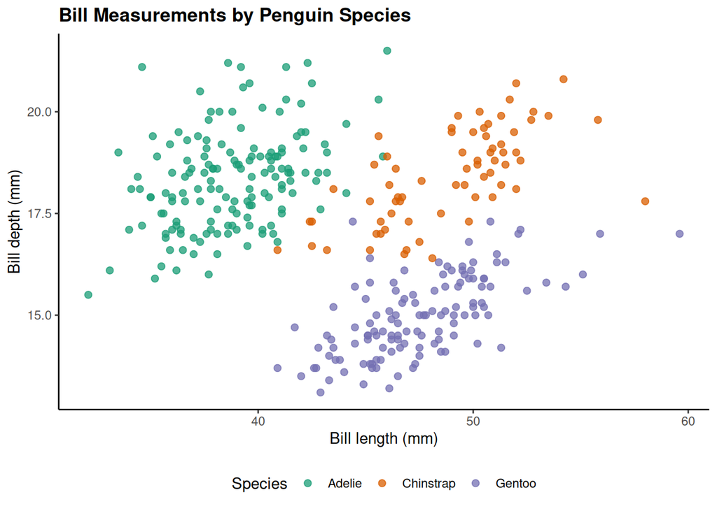

```r
# Compare bill measurements among the penguin species.
ggplot(
  data = penguins,
  aes(
    x = bill_length_mm,
    y = bill_depth_mm,
    color = species
  )
) +
  geom_point(
    alpha = 0.75,
    size = 2,
    na.rm = TRUE
  ) +
  labs(
    title = "Bill Measurements by Penguin Species",
    x = "Bill length (mm)",
    y = "Bill depth (mm)",
    color = "Species"
  ) +
  scale_color_brewer(palette = "Dark2") +
  theme_classic() +
  theme(
    legend.position = "bottom",
    plot.title = element_text(face = "bold")
  )
```

The species form different groups based on bill measurements. Adelie penguins generally have shorter bills, Chinstrap penguins generally have longer bills, and Gentoo penguins generally have shallower bills.

## Penguin species observed at each island

The following bar chart compares the penguin species observed at Biscoe, Dream, and Torgersen islands.

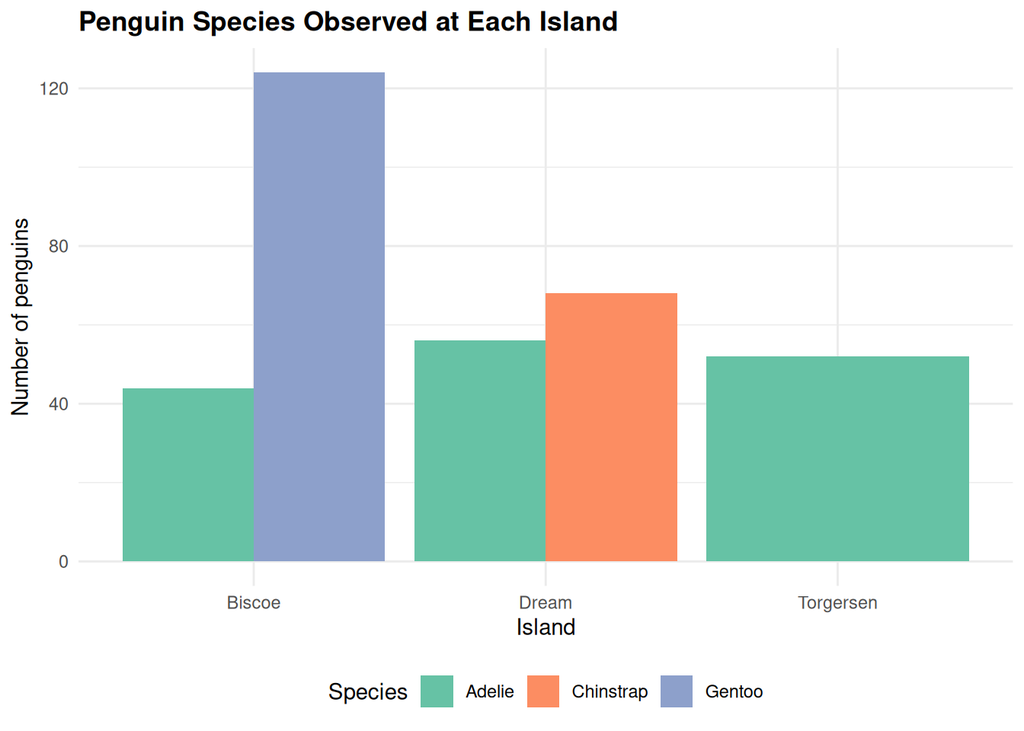

```r
# Count species observations at each island.
ggplot(
  data = penguins,
  aes(x = island, fill = species)
) +
  geom_bar(position = "dodge") +
  labs(
    title = "Penguin Species Observed at Each Island",
    x = "Island",
    y = "Number of penguins",
    fill = "Species"
  ) +
  scale_fill_brewer(palette = "Set2") +
  theme_minimal() +
  theme(
    legend.position = "bottom",
    plot.title = element_text(face = "bold")
  )
```

Adelie penguins were observed on all three islands. Chinstrap penguins were observed at Dream Island, while Gentoo penguins were observed at Biscoe Island.